# HW5

b05702032

匯入套件

匯入資料 資料為主計處薪資及生產力統計資料，這裡只以服務業來進行分析

```r
service <- read_csv("C:/Users/Daniel Chiang/Desktop/HW5/service.csv")
```

進行相關性分析

```r
require(reshape2)
require(scales)
```

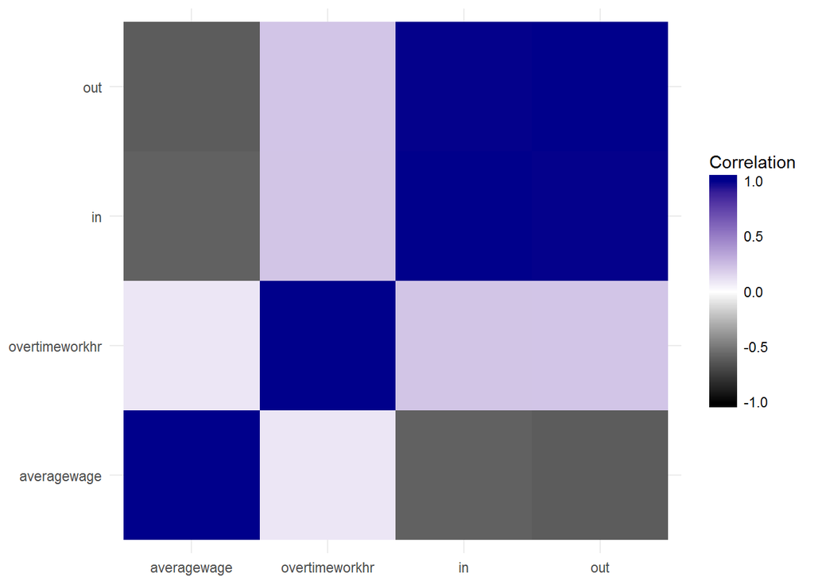

```r
serCor<-cor(service[,c(3,9:11)])
serMelt<-melt(serCor,varnames = c("x","y"),value.name = "Correlation")
serMelt<-serMelt[order(serMelt$Correlation),]
ggplot(serMelt,aes(x=x,y=y))+
  geom_tile(aes(fill=Correlation))+
  scale_fill_gradient2(low="black",mid="white",high="darkblue",guide=guide_colorbar(ticks=FALSE,barheight=10),limits=c(-1,1))+
  theme_minimal()+
  labs(x=NULL,y=NULL)
```

黑色表示負相關，藍色表示正相關，可以看出薪資和離職呈現負相關，而加班工時雖也和離職成正相關，新進部分，和薪資呈現負相關，但相關性較小；和加班工時成正相關，推估可能薪資較低希望可以有加班的機會。

進行t檢定

```r
t.test(service$averagewage,alternative = "two.sided",mu=22000)
```

```
##
##  One Sample t-test
##
## data:  service$averagewage
## t = 5.1221, df = 11, p-value = 0.0003324
## alternative hypothesis: true mean is not equal to 22000
## 95 percent confidence interval:
##  37038.75 59701.75
## sample estimates:
## mean of x
##  48370.25
```

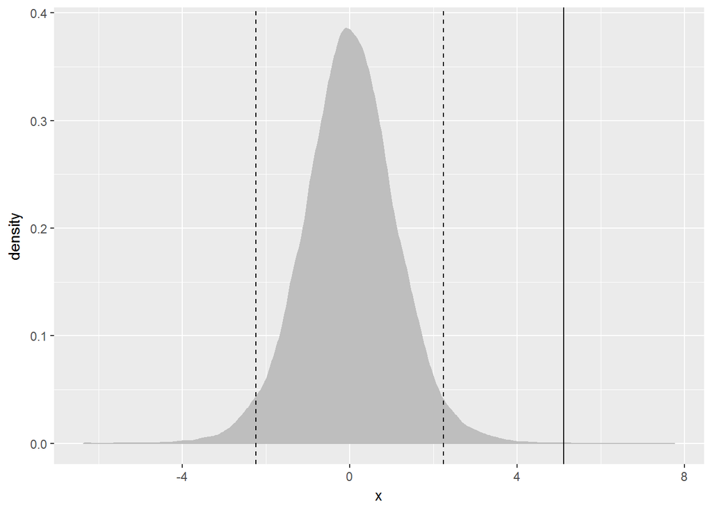

```r
randT<-rt(30000,df=NROW(service)-1)
serTTest<-t.test(service$averagewage,alternative = "two.sided",mu=22000)

ggplot(data.frame(x=randT))+
  geom_density(aes(x=x),fill="grey",color="grey")+
  geom_vline(xintercept = serTTest$statistic)+
  geom_vline(xintercept = mean(randT)+c(-2,2)*sd(randT),linetype=2)
```

假設薪資為22k進行預測，虛線為平均數左右兩個標準差，實現為t統計量，可以看到它離開分佈有一段距離，我們可知道平均值不等於22k，所以基本上在服務業可能起薪低於平均，但長期來看，薪資會再提高，平均不只22k。

ANOVA分析

```r
services <- read_csv("C:/Users/Daniel Chiang/Desktop/HW5/services.csv")
serAnova<-aov(averagewage~career-1 ,services)
summary(serAnova)
```

```
##           Df    Sum Sq   Mean Sq F value Pr(>F)
## career    12 1.204e+11 1.004e+10    4219 <2e-16 ***
## Residuals 36 8.563e+07 2.379e+06
## ---
## Signif. codes:  0 '***' 0.001 '**' 0.01 '*' 0.05 '.' 0.1 ' ' 1
```

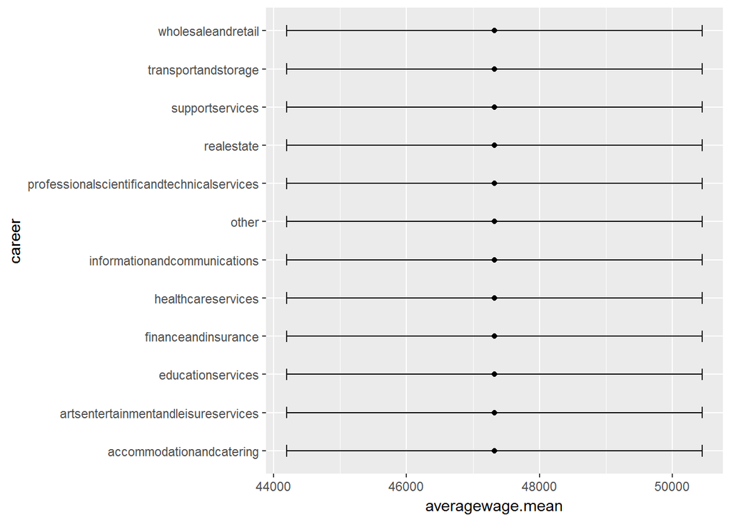

```r
serout<-ddply(services,"career",summarise,
              averagewage.mean=mean(services$averagewage),
              averagewage.sd=sd(services$averagewage),
              Length=NROW(services$averagewage),
              tfrac=qt(p=0.90,df=Length-1),
              Lower=averagewage.mean-tfrac*averagewage.sd/sqrt(Length),
              Upper=averagewage.mean+tfrac*averagewage.sd/sqrt(Length))

ggplot(serout,aes(x=averagewage.mean,y=career))+geom_point()+
  geom_errorbarh(aes(xmin=Lower,xmax=Upper),height=0.3)
```